# Functions and Tidy Data

j4yr0u93

10/5/2020

# 1

```
## [1] "orange" "plum"   "apple"  "plum"   "apple"  "kiwi"   "banana"
```

# 2

```
##       mean
## 1 56.47840
## 2 57.38795
## 3 57.10168
## 4 56.78660
## 5 55.69162
```

# 3

```
##    og_stat boot_stat_mean upper_CI lower_CI       bias
## 1 56.92357        57.0826 58.64438 55.29862 -0.1590356
```

# 4a

```
## # A tibble: 6 x 38
##   question_id poll_id cycle state pollster_id pollster sponsor_ids sponsors
##         <dbl>   <dbl> <dbl> <chr>       <dbl> <chr>          <dbl> <chr>
## 1      131666   70576  2020 Nort~         383 Public ~          NA <NA>
## 2      131666   70576  2020 Nort~         383 Public ~          NA <NA>
## 3      131649   70573  2020 <NA>         1189 Morning~          NA <NA>
## 4      131649   70573  2020 <NA>         1189 Morning~          NA <NA>
## 5      131811   70578  2020 Utah         1243 Y2 Anal~          NA <NA>
## 6      131811   70578  2020 Utah         1243 Y2 Anal~          NA <NA>
## # ... with 30 more variables: display_name <chr>, pollster_rating_id <dbl>,
## #   pollster_rating_name <chr>, fte_grade <chr>, sample_size <dbl>,
## #   population <chr>, population_full <chr>, methodology <chr>,
## #   office_type <chr>, seat_number <dbl>, seat_name <lgl>, start_date <chr>,
## #   end_date <chr>, election_date <chr>, sponsor_candidate <chr>,
## #   internal <lgl>, partisan <chr>, tracking <lgl>, nationwide_batch <lgl>,
## #   ranked_choice_reallocated <lgl>, created_at <chr>, notes <chr>, url <chr>,
## #   stage <chr>, race_id <dbl>, answer <chr>, candidate_id <dbl>,
## #   candidate_name <chr>, candidate_party <chr>, pct <dbl>
```

data appears to be hybrid

# 4b

```
## # A tibble: 6 x 38
##   question_id poll_id cycle state pollster_id pollster sponsor_ids sponsors
##         <dbl>   <dbl> <dbl> <chr>       <dbl> <chr>          <dbl> <chr>
## 1      131666   70576  2020 Nort~         383 Public ~          NA <NA>
## 2      131666   70576  2020 Nort~         383 Public ~          NA <NA>
## 3      131649   70573  2020 <NA>         1189 Morning~          NA <NA>
## 4      131649   70573  2020 <NA>         1189 Morning~          NA <NA>
## 5      131592   70546  2020 <NA>          744 Ipsos             NA <NA>
## 6      131592   70546  2020 <NA>          744 Ipsos             NA <NA>
## # ... with 30 more variables: display_name <chr>, pollster_rating_id <dbl>,
## #   pollster_rating_name <chr>, fte_grade <chr>, sample_size <dbl>,
## #   population <chr>, population_full <chr>, methodology <chr>,
## #   office_type <chr>, seat_number <dbl>, seat_name <lgl>, start_date <chr>,
## #   end_date <chr>, election_date <chr>, sponsor_candidate <chr>,
## #   internal <lgl>, partisan <chr>, tracking <lgl>, nationwide_batch <lgl>,
## #   ranked_choice_reallocated <lgl>, created_at <chr>, notes <chr>, url <chr>,
## #   stage <chr>, race_id <dbl>, answer <chr>, candidate_id <dbl>,
## #   candidate_name <chr>, candidate_party <chr>, pct <dbl>
```

# 4c

```
## # A tibble: 2 x 2
## # Groups:   answer [2]
##   answer pol_avg
##   <chr>    <dbl>
## 1 Biden     49.2
## 2 Trump     41.0
```

# 4d

```
## # A tibble: 10 x 2
##    state          `stat_boot(diff, 1)$mean`
##    <chr>                              <dbl>
##  1 Arizona                             6
##  2 Florida                             5
##  3 Georgia                             1
##  4 Michigan                            5
##  5 Missouri                           -5
##  6 New Hampshire                       3
##  7 North Carolina                      2
##  8 Ohio                                0
##  9 Pennsylvania                        7
## 10 National                            7.15
```

# 5a

We get an extra large and nasty matrix thing of 50 by 1000 vals, I don’t like it.

# 5b

```
## # A tibble: 6 x 2
##   sim     pct
##   <chr> <dbl>
## 1 V1     47.7
## 2 V2     48.4
## 3 V3     48.7
## 4 V4     47.6
## 5 V5     44.2
## 6 V6     49.1
```

This looks way better pivoting it just peeking it. Actually seems readable, not that I would read 50k entries.

# 5c

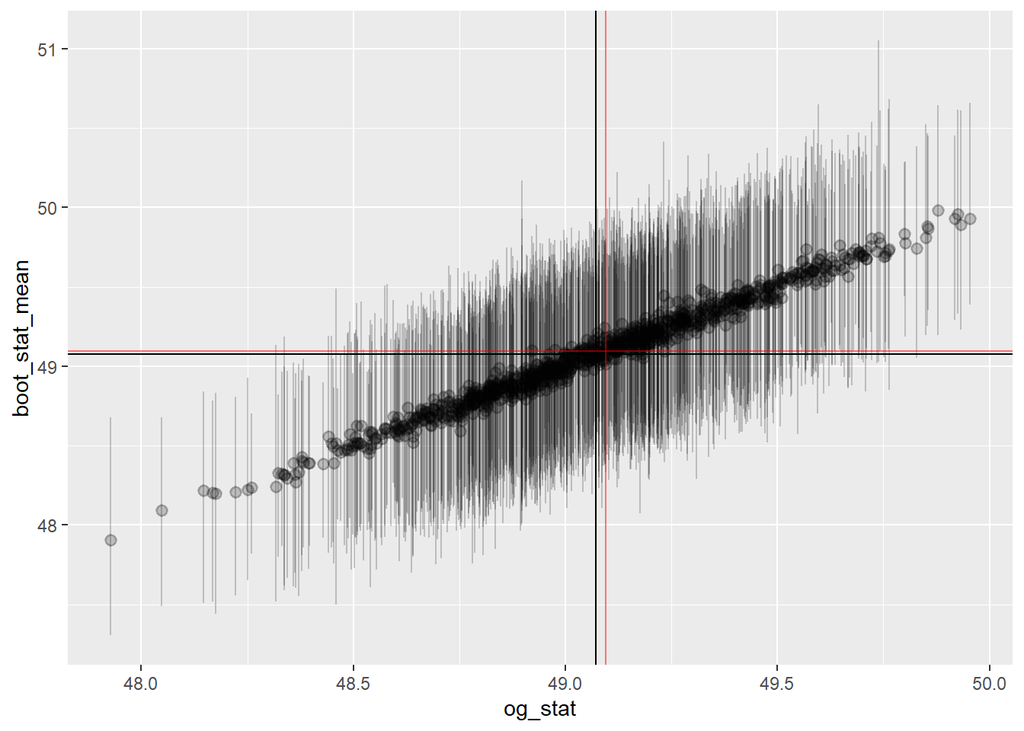

```
## [1] "A is 486 and B is 475"
```

The bootstrapped mean was greater than original A times. The sample mean was greater than the original B times.

# 5d

The black intercepts above are means of each axis and the red lines are both the actual means from the pol (visually see difference between boot mean and og mean, as well as sample mean and og mean). Something weird might be going on. CIs formed the lines on each point which just shows the proximal range the simulation occupied for a given point. They also indicate if a simulation contained the true mean when seeing if the red line falls on them.

# cool current biden map

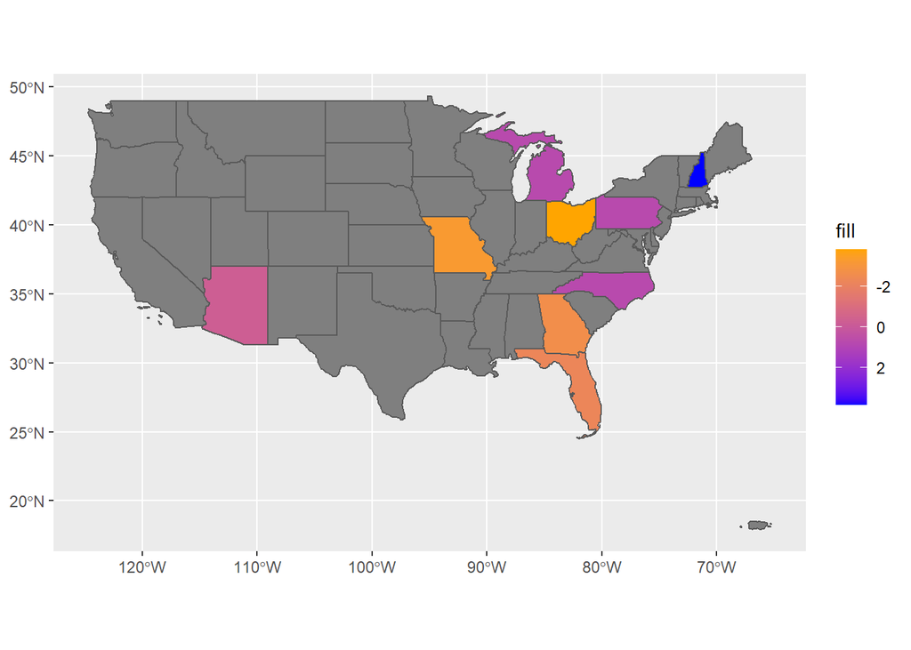

# git extra credit

pushed my repo and submitting the whole repo as hw  
[HW_4 github link](https://github.com/j4yr0u93/HW_4)